# Data Mining Week 3: Classification

- Binary Classification
- Logistic Regression
- KNN
- Evaluation Methods

```python
# Get working directory
import os
os.getcwd()
```

```
'/Users/matthewberezo'
```

```python
# Read in csv file for IBM Telco data that is stored in path:
import pandas as pd
pd.set_option('display.max_columns', None)
ibm_telco = pd.read_csv('/Users/matthewberezo/Documents/ibm_telco.csv')
```

```python
#Preview the dataset
ibm_telco.head()
```

|  | customerID | gender | SeniorCitizen | Partner | Dependents | tenure | PhoneService | MultipleLines | InternetService | OnlineSecurity | OnlineBackup | DeviceProtection | TechSupport | StreamingTV | StreamingMovies | Contract | PaperlessBilling | PaymentMethod | MonthlyCharges | TotalCharges | Churn |
| --- | --- | --- | --- | --- | --- | --- | --- | --- | --- | --- | --- | --- | --- | --- | --- | --- | --- | --- | --- | --- | --- |
| 0 | 7590-VHVEG | Female | 0 | Yes | No | 1 | No | No phone service | DSL | No | Yes | No | No | No | No | Month-to-month | Yes | Electronic check | 29.85 | 29.85 | No |
| 1 | 5575-GNVDE | Male | 0 | No | No | 34 | Yes | No | DSL | Yes | No | Yes | No | No | No | One year | No | Mailed check | 56.95 | 1889.5 | No |
| 2 | 3668-QPYBK | Male | 0 | No | No | 2 | Yes | No | DSL | Yes | Yes | No | No | No | No | Month-to-month | Yes | Mailed check | 53.85 | 108.15 | Yes |
| 3 | 7795-CFOCW | Male | 0 | No | No | 45 | No | No phone service | DSL | Yes | No | Yes | Yes | No | No | One year | No | Bank transfer (automatic) | 42.30 | 1840.75 | No |
| 4 | 9237-HQITU | Female | 0 | No | No | 2 | Yes | No | Fiber optic | No | No | No | No | No | No | Month-to-month | Yes | Electronic check | 70.70 | 151.65 | Yes |

```python
# We again see that the describe function only describes continuous variables
ibm_telco.describe()
```

|  | SeniorCitizen | tenure | MonthlyCharges |
| --- | --- | --- | --- |
| count | 7043.000000 | 7043.000000 | 7043.000000 |
| mean | 0.162147 | 32.371149 | 64.761692 |
| std | 0.368612 | 24.559481 | 30.090047 |
| min | 0.000000 | 0.000000 | 18.250000 |
| 25% | 0.000000 | 9.000000 | 35.500000 |
| 50% | 0.000000 | 29.000000 | 70.350000 |
| 75% | 0.000000 | 55.000000 | 89.850000 |
| max | 1.000000 | 72.000000 | 118.750000 |

```python
#Check dataframe shape
ibm_telco.shape
```

```
(7043, 21)
```

```python
#Check nulls per column
ibm_telco.isnull().sum(axis = 0)
```

```
customerID          0
gender              0
SeniorCitizen       0
Partner             0
Dependents          0
tenure              0
PhoneService        0
MultipleLines       0
InternetService     0
OnlineSecurity      0
OnlineBackup        0
DeviceProtection    0
TechSupport         0
StreamingTV         0
StreamingMovies     0
Contract            0
PaperlessBilling    0
PaymentMethod       0
MonthlyCharges      0
TotalCharges        0
Churn               0
dtype: int64
```

```python
#Check datatypes
ibm_telco.dtypes
```

```
customerID           object
gender               object
SeniorCitizen         int64
Partner              object
Dependents           object
tenure                int64
PhoneService         object
MultipleLines        object
InternetService      object
OnlineSecurity       object
OnlineBackup         object
DeviceProtection     object
TechSupport          object
StreamingTV          object
StreamingMovies      object
Contract             object
PaperlessBilling     object
PaymentMethod        object
MonthlyCharges      float64
TotalCharges         object
Churn                object
dtype: object
```

```python
#It is usually useful to see the unique values for categorical variables that may not be obvious
ibm_telco.SeniorCitizen.unique()
```

```
array([0, 1])
```

```python
ibm_telco.Partner.unique()
```

```
array(['Yes', 'No'], dtype=object)
```

```python
ibm_telco.Dependents.unique()
```

```
array(['No', 'Yes'], dtype=object)
```

```python
ibm_telco.PhoneService.unique()
```

```
array(['No', 'Yes'], dtype=object)
```

```python
ibm_telco.MultipleLines.unique()
```

```
array(['No phone service', 'No', 'Yes'], dtype=object)
```

```python
ibm_telco.InternetService.unique()
```

```
array(['DSL', 'Fiber optic', 'No'], dtype=object)
```

```python
ibm_telco.OnlineSecurity.unique()
```

```
array(['No', 'Yes', 'No internet service'], dtype=object)
```

```python
ibm_telco.OnlineBackup.unique()
```

```
array(['Yes', 'No', 'No internet service'], dtype=object)
```

```python
ibm_telco.DeviceProtection.unique()
```

```
array(['No', 'Yes', 'No internet service'], dtype=object)
```

```python
ibm_telco.TechSupport.unique()
```

```
array(['No', 'Yes', 'No internet service'], dtype=object)
```

```python
#Interestingly, TotalCharges is a categorical variable.  We may be able to convert this to numeric
ibm_telco.TotalCharges.unique()
```

```
array(['29.85', '1889.5', '108.15', ..., '346.45', '306.6', '6844.5'],
      dtype=object)
```

#### It's important to understand the true proportion of our target, which in this case is customer churn:

```python
ibm_telco.groupby('Churn')['customerID'].nunique()
```

```
Churn
No     5174
Yes    1869
Name: customerID, dtype: int64
```

```python
# % of churned:
1869/(1869+5174)
```

```
0.2653698707936959
```

```python
# % of not churned
5174/(1869+5174)
```

```
0.7346301292063041
```

### Handling categorical predictors:

There are different techniques when it comes to handling categorical data in python, such as:

- Replacing values
- Encoding labels
- one-hot encoding

Let's look at a couple of these examples as to how we can use these different methods, and then extend that logic for the rest of the categorical features

### Replacing values

For replacing features, we have to first create a dictionary that contains mapping numbers for each category in the column. The easiest example for this is with the gender column. As we will see, this could be a tedious process for columns with many different categories

```python
gender_map = {'gender': {'Male': 1, 'Female': 2}}
```

```python
gender_map
```

```
{'gender': {'Male': 1, 'Female': 2}}
```

```python
ibm_telco_replace_ex_df = ibm_telco.copy()
```

```python
labels = ibm_telco_replace_ex_df['gender'].astype('category').cat.categories.tolist()
```

```python
labels
```

```
['Female', 'Male']
```

```python
replace_map_comp = {'gender' : {k: v for k,v in zip(labels,list(range(1,len(labels)+1)))}}
```

```python
replace_map_comp
```

```
{'gender': {'Female': 1, 'Male': 2}}
```

```python
ibm_telco_replace_ex_df.replace(replace_map_comp, inplace=True)
```

```python
ibm_telco_replace_ex_df.head()
```

|  | customerID | gender | SeniorCitizen | Partner | Dependents | tenure | PhoneService | MultipleLines | InternetService | OnlineSecurity | OnlineBackup | DeviceProtection | TechSupport | StreamingTV | StreamingMovies | Contract | PaperlessBilling | PaymentMethod | MonthlyCharges | TotalCharges | Churn |
| --- | --- | --- | --- | --- | --- | --- | --- | --- | --- | --- | --- | --- | --- | --- | --- | --- | --- | --- | --- | --- | --- |
| 0 | 7590-VHVEG | 1 | 0 | Yes | No | 1 | No | No phone service | DSL | No | Yes | No | No | No | No | Month-to-month | Yes | Electronic check | 29.85 | 29.85 | No |
| 1 | 5575-GNVDE | 2 | 0 | No | No | 34 | Yes | No | DSL | Yes | No | Yes | No | No | No | One year | No | Mailed check | 56.95 | 1889.5 | No |
| 2 | 3668-QPYBK | 2 | 0 | No | No | 2 | Yes | No | DSL | Yes | Yes | No | No | No | No | Month-to-month | Yes | Mailed check | 53.85 | 108.15 | Yes |
| 3 | 7795-CFOCW | 2 | 0 | No | No | 45 | No | No phone service | DSL | Yes | No | Yes | Yes | No | No | One year | No | Bank transfer (automatic) | 42.30 | 1840.75 | No |
| 4 | 9237-HQITU | 1 | 0 | No | No | 2 | Yes | No | Fiber optic | No | No | No | No | No | No | Month-to-month | Yes | Electronic check | 70.70 | 151.65 | Yes |

#### As we can see, this is very tedious. Let's look at label encoding:

```python
ibm_telco_le_ex = ibm_telco.copy()

ibm_telco_le_ex['gender'] = ibm_telco_le_ex['gender'].astype('category')
ibm_telco_le_ex['gender_le'] = ibm_telco_le_ex['gender'].cat.codes
ibm_telco_le_ex.head()
```

|  | customerID | gender | SeniorCitizen | Partner | Dependents | tenure | PhoneService | MultipleLines | InternetService | OnlineSecurity | OnlineBackup | DeviceProtection | TechSupport | StreamingTV | StreamingMovies | Contract | PaperlessBilling | PaymentMethod | MonthlyCharges | TotalCharges | Churn | gender_le |
| --- | --- | --- | --- | --- | --- | --- | --- | --- | --- | --- | --- | --- | --- | --- | --- | --- | --- | --- | --- | --- | --- | --- |
| 0 | 7590-VHVEG | Female | 0 | Yes | No | 1 | No | No phone service | DSL | No | Yes | No | No | No | No | Month-to-month | Yes | Electronic check | 29.85 | 29.85 | No | 0 |
| 1 | 5575-GNVDE | Male | 0 | No | No | 34 | Yes | No | DSL | Yes | No | Yes | No | No | No | One year | No | Mailed check | 56.95 | 1889.5 | No | 1 |
| 2 | 3668-QPYBK | Male | 0 | No | No | 2 | Yes | No | DSL | Yes | Yes | No | No | No | No | Month-to-month | Yes | Mailed check | 53.85 | 108.15 | Yes | 1 |
| 3 | 7795-CFOCW | Male | 0 | No | No | 45 | No | No phone service | DSL | Yes | No | Yes | Yes | No | No | One year | No | Bank transfer (automatic) | 42.30 | 1840.75 | No | 1 |
| 4 | 9237-HQITU | Female | 0 | No | No | 2 | Yes | No | Fiber optic | No | No | No | No | No | No | Month-to-month | Yes | Electronic check | 70.70 | 151.65 | Yes | 0 |

```python
#### We can also on-hot these variables.  let's do this with the Partner column:
ibm_telco_onehot_ex = ibm_telco.copy()

ibm_telco_onehot_ex = pd.get_dummies(ibm_telco_onehot_ex, columns = ['Partner'], prefix = 'Partner')

ibm_telco_onehot_ex.head()
```

|  | customerID | gender | SeniorCitizen | Dependents | tenure | PhoneService | MultipleLines | InternetService | OnlineSecurity | OnlineBackup | DeviceProtection | TechSupport | StreamingTV | StreamingMovies | Contract | PaperlessBilling | PaymentMethod | MonthlyCharges | TotalCharges | Churn | Partner_No | Partner_Yes |
| --- | --- | --- | --- | --- | --- | --- | --- | --- | --- | --- | --- | --- | --- | --- | --- | --- | --- | --- | --- | --- | --- | --- |
| 0 | 7590-VHVEG | Female | 0 | No | 1 | No | No phone service | DSL | No | Yes | No | No | No | No | Month-to-month | Yes | Electronic check | 29.85 | 29.85 | No | 0 | 1 |
| 1 | 5575-GNVDE | Male | 0 | No | 34 | Yes | No | DSL | Yes | No | Yes | No | No | No | One year | No | Mailed check | 56.95 | 1889.5 | No | 1 | 0 |
| 2 | 3668-QPYBK | Male | 0 | No | 2 | Yes | No | DSL | Yes | Yes | No | No | No | No | Month-to-month | Yes | Mailed check | 53.85 | 108.15 | Yes | 1 | 0 |
| 3 | 7795-CFOCW | Male | 0 | No | 45 | No | No phone service | DSL | Yes | No | Yes | Yes | No | No | One year | No | Bank transfer (automatic) | 42.30 | 1840.75 | No | 1 | 0 |
| 4 | 9237-HQITU | Female | 0 | No | 2 | Yes | No | Fiber optic | No | No | No | No | No | No | Month-to-month | Yes | Electronic check | 70.70 | 151.65 | Yes | 1 | 0 |

## Logistic regression

As we walk through our logistic regression example(s), we will label encode our categorical variables for the sake of time.

```python
ibm_telco.head()
```

|  | customerID | gender | SeniorCitizen | Partner | Dependents | tenure | PhoneService | MultipleLines | InternetService | OnlineSecurity | OnlineBackup | DeviceProtection | TechSupport | StreamingTV | StreamingMovies | Contract | PaperlessBilling | PaymentMethod | MonthlyCharges | TotalCharges | Churn |
| --- | --- | --- | --- | --- | --- | --- | --- | --- | --- | --- | --- | --- | --- | --- | --- | --- | --- | --- | --- | --- | --- |
| 0 | 7590-VHVEG | Female | 0 | Yes | No | 1 | No | No phone service | DSL | No | Yes | No | No | No | No | Month-to-month | Yes | Electronic check | 29.85 | 29.85 | No |
| 1 | 5575-GNVDE | Male | 0 | No | No | 34 | Yes | No | DSL | Yes | No | Yes | No | No | No | One year | No | Mailed check | 56.95 | 1889.5 | No |
| 2 | 3668-QPYBK | Male | 0 | No | No | 2 | Yes | No | DSL | Yes | Yes | No | No | No | No | Month-to-month | Yes | Mailed check | 53.85 | 108.15 | Yes |
| 3 | 7795-CFOCW | Male | 0 | No | No | 45 | No | No phone service | DSL | Yes | No | Yes | Yes | No | No | One year | No | Bank transfer (automatic) | 42.30 | 1840.75 | No |
| 4 | 9237-HQITU | Female | 0 | No | No | 2 | Yes | No | Fiber optic | No | No | No | No | No | No | Month-to-month | Yes | Electronic check | 70.70 | 151.65 | Yes |

```python
# Contingent on memory, I like to keep the original column values in case we need them again or make a mistake as we continue
#coding

ibm_telco['gender'] = ibm_telco['gender'].astype('category')
ibm_telco['gender_le'] = ibm_telco['gender'].cat.codes

ibm_telco['Partner'] = ibm_telco['Partner'].astype('category')
ibm_telco['Partner_le'] = ibm_telco['Partner'].cat.codes

ibm_telco['Dependents'] = ibm_telco['Dependents'].astype('category')
ibm_telco['Dependents_le'] = ibm_telco['Dependents'].cat.codes

ibm_telco['PhoneService'] = ibm_telco['PhoneService'].astype('category')
ibm_telco['PhoneService_le'] = ibm_telco['PhoneService'].cat.codes

ibm_telco['MultipleLines'] = ibm_telco['MultipleLines'].astype('category')
ibm_telco['MultipleLines_le'] = ibm_telco['MultipleLines'].cat.codes

ibm_telco['InternetService'] = ibm_telco['InternetService'].astype('category')
ibm_telco['InternetService_le'] = ibm_telco['InternetService'].cat.codes

ibm_telco['OnlineSecurity'] = ibm_telco['OnlineSecurity'].astype('category')
ibm_telco['OnlineSecurity_le'] = ibm_telco['OnlineSecurity'].cat.codes

ibm_telco['OnlineBackup'] = ibm_telco['OnlineBackup'].astype('category')
ibm_telco['OnlineBackup_le'] = ibm_telco['OnlineBackup'].cat.codes

ibm_telco['DeviceProtection'] = ibm_telco['DeviceProtection'].astype('category')
ibm_telco['DeviceProtection_le'] = ibm_telco['DeviceProtection'].cat.codes

ibm_telco['TechSupport'] = ibm_telco['TechSupport'].astype('category')
ibm_telco['TechSupport_le'] = ibm_telco['TechSupport'].cat.codes

ibm_telco['StreamingTV'] = ibm_telco['StreamingTV'].astype('category')
ibm_telco['StreamingTV_le'] = ibm_telco['StreamingTV'].cat.codes

ibm_telco['StreamingMovies'] = ibm_telco['StreamingMovies'].astype('category')
ibm_telco['StreamingMovies_le'] = ibm_telco['StreamingMovies'].cat.codes

ibm_telco['Contract'] = ibm_telco['Contract'].astype('category')
ibm_telco['Contract_le'] = ibm_telco['Contract'].cat.codes

ibm_telco['PaperlessBilling'] = ibm_telco['PaperlessBilling'].astype('category')
ibm_telco['PaperlessBilling_le'] = ibm_telco['PaperlessBilling'].cat.codes

ibm_telco['PaymentMethod'] = ibm_telco['PaymentMethod'].astype('category')
ibm_telco['PaymentMethod_le'] = ibm_telco['PaymentMethod'].cat.codes
```

```python
ibm_telco.head()
```

|  | customerID | gender | SeniorCitizen | Partner | Dependents | tenure | PhoneService | MultipleLines | InternetService | OnlineSecurity | OnlineBackup | DeviceProtection | TechSupport | StreamingTV | StreamingMovies | Contract | PaperlessBilling | PaymentMethod | MonthlyCharges | TotalCharges | Churn | gender_le | Partner_le | Dependents_le | PhoneService_le | MultipleLines_le | InternetService_le | OnlineSecurity_le | OnlineBackup_le | … |
| --- | --- | --- | --- | --- | --- | --- | --- | --- | --- | --- | --- | --- | --- | --- | --- | --- | --- | --- | --- | --- | --- | --- | --- | --- | --- | --- | --- | --- | --- | --- |
| 0 | 7590-VHVEG | Female | 0 | Yes | No | 1 | No | No phone service | DSL | No | Yes | No | No | No | No | Month-to-month | Yes | Electronic check | 29.85 | 29.85 | No | 0 | 1 | 0 | 0 | 1 | 0 | 0 | 2 | … |
| 1 | 5575-GNVDE | Male | 0 | No | No | 34 | Yes | No | DSL | Yes | No | Yes | No | No | No | One year | No | Mailed check | 56.95 | 1889.5 | No | 1 | 0 | 0 | 1 | 0 | 0 | 2 | 0 | … |
| 2 | 3668-QPYBK | Male | 0 | No | No | 2 | Yes | No | DSL | Yes | Yes | No | No | No | No | Month-to-month | Yes | Mailed check | 53.85 | 108.15 | Yes | 1 | 0 | 0 | 1 | 0 | 0 | 2 | 2 | … |
| 3 | 7795-CFOCW | Male | 0 | No | No | 45 | No | No phone service | DSL | Yes | No | Yes | Yes | No | No | One year | No | Bank transfer (automatic) | 42.30 | 1840.75 | No | 1 | 0 | 0 | 0 | 1 | 0 | 2 | 0 | … |
| 4 | 9237-HQITU | Female | 0 | No | No | 2 | Yes | No | Fiber optic | No | No | No | No | No | No | Month-to-month | Yes | Electronic check | 70.70 | 151.65 | Yes | 0 | 0 | 0 | 1 | 0 | 1 | 0 | 0 | … |

```python
# We will also have to convert the target to a numerical value, although it's a category.  Since this is so important,
# we will not use the label encoder for this.  Instead, we will do this manually
```

```python
ibm_telco['Churn'].unique()
```

```
array(['No', 'Yes'], dtype=object)
```

```python
import numpy as np
ibm_telco['CHURN'] = np.where(ibm_telco['Churn'] == 'Yes', 1, 0)
```

```python
target = ibm_telco[['CHURN', 'customerID']]
```

```python
ibm_telco_vars = ibm_telco.drop(['Churn', 'CHURN', 'customerID', 'gender', 'SeniorCitizen', 'Partner', 'Dependents',
                                'PhoneService', 'MultipleLines', 'InternetService', 'OnlineSecurity', 'OnlineBackup',
                                'DeviceProtection', 'TechSupport', 'StreamingTV', 'StreamingMovies', 'Contract',
                                'PaperlessBilling', 'PaymentMethod'], axis=1)
```

```python
ibm_telco_vars.head()
```

|  | tenure | MonthlyCharges | TotalCharges | gender_le | Partner_le | Dependents_le | PhoneService_le | MultipleLines_le | InternetService_le | OnlineSecurity_le | OnlineBackup_le | DeviceProtection_le | TechSupport_le | StreamingTV_le | StreamingMovies_le | Contract_le | PaperlessBilling_le | PaymentMethod_le |
| --- | --- | --- | --- | --- | --- | --- | --- | --- | --- | --- | --- | --- | --- | --- | --- | --- | --- | --- |
| 0 | 1 | 29.85 | 29.85 | 0 | 1 | 0 | 0 | 1 | 0 | 0 | 2 | 0 | 0 | 0 | 0 | 0 | 1 | 2 |
| 1 | 34 | 56.95 | 1889.5 | 1 | 0 | 0 | 1 | 0 | 0 | 2 | 0 | 2 | 0 | 0 | 0 | 1 | 0 | 3 |
| 2 | 2 | 53.85 | 108.15 | 1 | 0 | 0 | 1 | 0 | 0 | 2 | 2 | 0 | 0 | 0 | 0 | 0 | 1 | 3 |
| 3 | 45 | 42.30 | 1840.75 | 1 | 0 | 0 | 0 | 1 | 0 | 2 | 0 | 2 | 2 | 0 | 0 | 1 | 0 | 0 |
| 4 | 2 | 70.70 | 151.65 | 0 | 0 | 0 | 1 | 0 | 1 | 0 | 0 | 0 | 0 | 0 | 0 | 0 | 1 | 2 |

```python
# We are going to convert the TotalCharges to numeric.  However, there are blank spaces in the column, which will
# cause errors as we are trying to convert it.  We can coerce these errors for now, which will make these black observations
# null, but we will have to either impute values for the logistic regression, or, drop the records.

#For simplicity, we will impute
ibm_telco_vars['TotalCharges'] = ibm_telco_vars['TotalCharges'].apply(pd.to_numeric, errors = 'coerce')

from sklearn.preprocessing import Imputer
mean_imputer = Imputer(missing_values='NaN', strategy='mean', axis=0)
ibm_telco_vars['TotalCharges'] = ibm_telco_vars['TotalCharges'].fillna(ibm_telco_vars['TotalCharges'].mean())
```

```python
ibm_telco_vars.dtypes
```

```
tenure                   int64
MonthlyCharges         float64
TotalCharges           float64
gender_le                 int8
Partner_le                int8
Dependents_le             int8
PhoneService_le           int8
MultipleLines_le          int8
InternetService_le        int8
OnlineSecurity_le         int8
OnlineBackup_le           int8
DeviceProtection_le       int8
TechSupport_le            int8
StreamingTV_le            int8
StreamingMovies_le        int8
Contract_le               int8
PaperlessBilling_le       int8
PaymentMethod_le          int8
dtype: object
```

```python
# Again, we split the data into training and testing
from sklearn.model_selection import train_test_split
x_train, x_test, y_train, y_test = train_test_split(ibm_telco_vars,
                                                    target,
                                                    test_size=0.2,
                                                    random_state=1)
```

#### Since we are doing classification, we want to make sure the distribution of our target is in our train and test sets are not only similar to one another, but similar to our population as a whole:

```python
y_train.groupby('CHURN')['customerID'].nunique()
```

```
CHURN
0    4113
1    1521
Name: customerID, dtype: int64
```

```python
1521/(1521+4113)
```

```
0.26996805111821087
```

```python
y_test.groupby('CHURN')['customerID'].nunique()
```

```
CHURN
0    1061
1     348
Name: customerID, dtype: int64
```

```python
348/(348+1061)
```

```
0.24698367636621718
```

### We can see that our dataset is imbalanced. Sometimes, we may want to downsample the negative class or upsample the positive class. For the sake of time, we will not do this during this exercise. Can anyone thinkn as to why we would want to do this?

```python
from sklearn.linear_model import LogisticRegression
from sklearn.preprocessing import StandardScaler

# Create logistic regression object
clf = LogisticRegression(random_state=0)
```

```python
x_train_vars_only = x_train.apply(pd.to_numeric)
```

```python
x_train.head()
```

|  | tenure | MonthlyCharges | TotalCharges | gender_le | Partner_le | Dependents_le | PhoneService_le | MultipleLines_le | InternetService_le | OnlineSecurity_le | OnlineBackup_le | DeviceProtection_le | TechSupport_le | StreamingTV_le | StreamingMovies_le | Contract_le | PaperlessBilling_le | PaymentMethod_le |
| --- | --- | --- | --- | --- | --- | --- | --- | --- | --- | --- | --- | --- | --- | --- | --- | --- | --- | --- |
| 1814 | 12 | 19.70 | 258.35 | 1 | 1 | 1 | 1 | 0 | 2 | 1 | 1 | 1 | 1 | 1 | 1 | 2 | 0 | 3 |
| 5946 | 42 | 73.90 | 3160.55 | 0 | 0 | 0 | 1 | 0 | 0 | 2 | 2 | 2 | 2 | 0 | 2 | 1 | 0 | 1 |
| 3881 | 71 | 65.15 | 4681.75 | 1 | 1 | 0 | 1 | 2 | 0 | 2 | 2 | 0 | 2 | 0 | 0 | 2 | 0 | 0 |
| 2389 | 71 | 85.45 | 6300.85 | 1 | 1 | 1 | 1 | 2 | 0 | 2 | 0 | 2 | 2 | 2 | 2 | 1 | 0 | 2 |
| 3676 | 30 | 70.40 | 2044.75 | 1 | 0 | 0 | 1 | 0 | 0 | 2 | 2 | 0 | 2 | 2 | 0 | 1 | 0 | 2 |

```python
y_train['CHURN'] = y_train['CHURN'].apply(pd.to_numeric)
```

```python
# Train model
model = clf.fit(x_train_vars_only, y_train['CHURN'])
```

```python
#We can look at our model's coefficients for respective columns
model.coef_
```

```
array([[-6.98238104e-02,  1.45069895e-02,  4.26986258e-04,
        -7.74353751e-02,  2.08528185e-02, -1.41475141e-01,
        -3.35602930e-01,  9.59530868e-02,  5.67449090e-02,
        -2.92121608e-01, -1.36205130e-01, -9.62198623e-02,
        -2.87562954e-01,  1.08018952e-02,  7.09837310e-02,
        -6.10309741e-01,  2.72547770e-01, -1.09910215e-02]])
```

```python
x_train.head()
```

|  | tenure | MonthlyCharges | TotalCharges | gender_le | Partner_le | Dependents_le | PhoneService_le | MultipleLines_le | InternetService_le | OnlineSecurity_le | OnlineBackup_le | DeviceProtection_le | TechSupport_le | StreamingTV_le | StreamingMovies_le | Contract_le | PaperlessBilling_le | PaymentMethod_le |
| --- | --- | --- | --- | --- | --- | --- | --- | --- | --- | --- | --- | --- | --- | --- | --- | --- | --- | --- |
| 1814 | 12 | 19.70 | 258.35 | 1 | 1 | 1 | 1 | 0 | 2 | 1 | 1 | 1 | 1 | 1 | 1 | 2 | 0 | 3 |
| 5946 | 42 | 73.90 | 3160.55 | 0 | 0 | 0 | 1 | 0 | 0 | 2 | 2 | 2 | 2 | 0 | 2 | 1 | 0 | 1 |
| 3881 | 71 | 65.15 | 4681.75 | 1 | 1 | 0 | 1 | 2 | 0 | 2 | 2 | 0 | 2 | 0 | 0 | 2 | 0 | 0 |
| 2389 | 71 | 85.45 | 6300.85 | 1 | 1 | 1 | 1 | 2 | 0 | 2 | 0 | 2 | 2 | 2 | 2 | 1 | 0 | 2 |
| 3676 | 30 | 70.40 | 2044.75 | 1 | 0 | 0 | 1 | 0 | 0 | 2 | 2 | 0 | 2 | 2 | 0 | 1 | 0 | 2 |

```python
# We can also perform logistic regression with the statsmodels package
import statsmodels.api as sm
logit_model=sm.Logit(y_train['CHURN'], x_train_vars_only)
result=logit_model.fit()
print(result.summary2())
```

```
Optimization terminated successfully.
         Current function value: 0.422386
         Iterations 8
                           Results: Logit
====================================================================
Model:                Logit             Pseudo R-squared:  0.276
Dependent Variable:   CHURN             AIC:               4795.4427
Date:                 2020-01-21 19:38  BIC:               4914.9011
No. Observations:     5634              Log-Likelihood:    -2379.7
Df Model:             17                LL-Null:           -3285.9
Df Residuals:         5616              LLR p-value:       0.0000
Converged:            1.0000            Scale:             1.0000
No. Iterations:       8.0000
--------------------------------------------------------------------
                     Coef.  Std.Err.    z     P>|z|   [0.025  0.975]
--------------------------------------------------------------------
tenure              -0.0677   0.0058 -11.6773 0.0000 -0.0791 -0.0563
MonthlyCharges       0.0212   0.0022   9.8185 0.0000  0.0169  0.0254
TotalCharges         0.0004   0.0001   6.5846 0.0000  0.0003  0.0005
gender_le           -0.0670   0.0703  -0.9535 0.3403 -0.2048  0.0707
Partner_le           0.0601   0.0852   0.7051 0.4807 -0.1070  0.2272
Dependents_le       -0.1402   0.0970  -1.4453 0.1484 -0.3303  0.0499
PhoneService_le     -1.1315   0.1512  -7.4824 0.0000 -1.4278 -0.8351
MultipleLines_le     0.0518   0.0447   1.1605 0.2458 -0.0357  0.1394
InternetService_le   0.2405   0.0717   3.3534 0.0008  0.0999  0.3810
OnlineSecurity_le   -0.2826   0.0451  -6.2660 0.0000 -0.3710 -0.1942
OnlineBackup_le     -0.1624   0.0422  -3.8447 0.0001 -0.2452 -0.0796
DeviceProtection_le -0.1184   0.0433  -2.7350 0.0062 -0.2032 -0.0336
TechSupport_le      -0.2737   0.0456  -6.0018 0.0000 -0.3631 -0.1843
StreamingTV_le      -0.0381   0.0459  -0.8292 0.4070 -0.1281  0.0519
StreamingMovies_le   0.0161   0.0458   0.3512 0.7254 -0.0737  0.1059
Contract_le         -0.7404   0.0844  -8.7708 0.0000 -0.9058 -0.5749
PaperlessBilling_le  0.3184   0.0803   3.9638 0.0001  0.1609  0.4758
PaymentMethod_le    -0.0054   0.0345  -0.1573 0.8750 -0.0730  0.0622
====================================================================
```

### So far, we have done no variable selection. We can perform this using scikit-learn's LogisticRegressionCV function. We also haven't cross-validated against test data as we always should. We will do that now.

This function implements logistic regression using liblinear, newton-cg, sag oflbfgs optimizer.

What is important to remember these optimizers is the following:

- liblinear solver supports L1 and L2 regularization, with a dual formulation only for the L2 penalty
- Elastic-net penalty is only supported by the saga solver

```python
# let's perform logistic regressino using elastic-net
from sklearn.linear_model import LogisticRegressionCV
from sklearn import metrics
clf = LogisticRegressionCV(solver = 'saga',
                           penalty = 'elasticnet',
                           l1_ratios = [0.1, 0.2, 0.3],
                           Cs = 20,
                           n_jobs = -1,
                           random_state = 0,
                           class_weight = 0.9
)
```

```python
# We may want to explore scaling the variables since alpha is impacted by the different scales of variables
scaler = StandardScaler()
x_train_vars_only_s = scaler.fit_transform(x_train_vars_only)

scaler = StandardScaler()
x_test_vars_only_s = scaler.fit_transform(x_test)
```

```python
clf_model = clf.fit(x_train_vars_only, y_train['CHURN'])
```

```python
clf_model_scaled = clf.fit(x_train_vars_only_s, y_train['CHURN'])
```

```python
# Let's fit an assess the results in terms of AUC on our training data
x_train_probs = clf_model.predict_proba(x_train_vars_only)
```

```python
x_train_probs_s = clf_model_scaled.predict_proba(x_train_vars_only_s)
```

```python
import numpy as np
print(x_train_probs.shape, x_train_probs_s.shape)
```

```
(5634, 2) (5634, 2)
```

```python
x_train_probs_s
```

```
array([[0.95695297, 0.04304703],
       [0.95299619, 0.04700381],
       [0.98845986, 0.01154014],
       ...,
       [0.3947514 , 0.6052486 ],
       [0.49201246, 0.50798754],
       [0.95607295, 0.04392705]])
```

```python
# Let's convert the array to a dataframe so that we can see what our probabilities look like
x_train_probs_df = pd.DataFrame(x_train_probs)
x_train_probs_df.columns = ['trainprobs' + str(col) for col in x_train_probs_df.columns]
x_train_probs_df.head()
```

|  | trainprobs0 | trainprobs1 |
| --- | --- | --- |
| 0 | 2.260526e-01 | 7.739474e-01 |
| 1 | 5.478413e-05 | 9.999452e-01 |
| 2 | 1.000000e+00 | 5.636006e-09 |
| 3 | 9.998187e-01 | 1.813154e-04 |
| 4 | 1.318273e-08 | 1.000000e+00 |

```python
x_train['predictions_1_s'] = x_train_probs_s[:,1]
```

```python
# We can insert our predictions into the original x_train dataframe:
x_train['predictions_1'] = x_train_probs[:,1]
```

```python
x_train.head()
```

|  | tenure | MonthlyCharges | TotalCharges | gender_le | Partner_le | Dependents_le | PhoneService_le | MultipleLines_le | InternetService_le | OnlineSecurity_le | OnlineBackup_le | DeviceProtection_le | TechSupport_le | StreamingTV_le | StreamingMovies_le | Contract_le | PaperlessBilling_le | PaymentMethod_le | predictions_1_s | predictions_1 |
| --- | --- | --- | --- | --- | --- | --- | --- | --- | --- | --- | --- | --- | --- | --- | --- | --- | --- | --- | --- | --- |
| 1814 | 12 | 19.70 | 258.35 | 1 | 1 | 1 | 1 | 0 | 2 | 1 | 1 | 1 | 1 | 1 | 1 | 2 | 0 | 3 | 0.043047 | 7.739474e-01 |
| 5946 | 42 | 73.90 | 3160.55 | 0 | 0 | 0 | 1 | 0 | 0 | 2 | 2 | 2 | 2 | 0 | 2 | 1 | 0 | 1 | 0.047004 | 9.999452e-01 |
| 3881 | 71 | 65.15 | 4681.75 | 1 | 1 | 0 | 1 | 2 | 0 | 2 | 2 | 0 | 2 | 0 | 0 | 2 | 0 | 0 | 0.011540 | 5.636006e-09 |
| 2389 | 71 | 85.45 | 6300.85 | 1 | 1 | 1 | 1 | 2 | 0 | 2 | 0 | 2 | 2 | 2 | 2 | 1 | 0 | 2 | 0.038521 | 1.813154e-04 |
| 3676 | 30 | 70.40 | 2044.75 | 1 | 0 | 0 | 1 | 0 | 0 | 2 | 2 | 0 | 2 | 2 | 0 | 1 | 0 | 2 | 0.067068 | 1.000000e+00 |

```python
# Let's see hwo our model performed in terms of AUC on our training data
from sklearn import metrics
fpr, tpr, thresholds = metrics.roc_curve(y_train['CHURN'], x_train['predictions_1'])
metrics.auc(fpr, tpr)
```

```
0.8027981066751196
```

```python
fpr, tpr, thresholds = metrics.roc_curve(y_train['CHURN'], x_train['predictions_1_s'])
metrics.auc(fpr, tpr)
```

```
0.8411188174696
```

```python
# It is important to make sure our AUC on train is not overfit and the model performs well on unseen data.
# This is where our test set comes in.  Let's fit the model on our test set and examine the results:
# Let's fit an assess the results in terms of AUC on our training data
x_test_probs = clf_model.predict_proba(x_test)
x_test_probs_s = clf_model_scaled.predict_proba(x_test_vars_only_s)
```

```python
x_test['predictions_1'] = x_test_probs[:,1]
x_test['predictions_1s'] = x_test_probs_s[:,1]
```

```python
fpr, tpr, thresholds = metrics.roc_curve(y_test['CHURN'], x_test['predictions_1'])
metrics.auc(fpr, tpr)
```

```
0.8017187212237425
```

```python
fpr, tpr, thresholds = metrics.roc_curve(y_test['CHURN'], x_test['predictions_1s'])
metrics.auc(fpr, tpr)
```

```
0.8535417140628554
```

```python
import numpy as np
from mpl_toolkits.mplot3d import Axes3D
import seaborn as sns
%matplotlib inline
sns.set(style='white', rc={'figure.figsize':(20,20)})
```

```python
y_train_r = y_train['CHURN']
```

```python
y_pred_prob_train = x_train['predictions_1']
```

```python
from sklearn.metrics import confusion_matrix, roc_curve, roc_auc_score
```

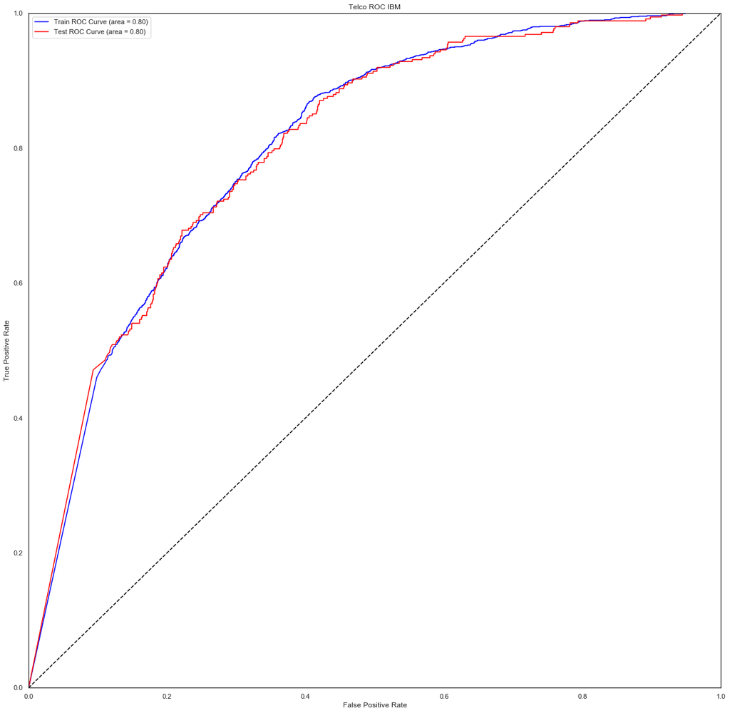

```python
# We can visualize these ROC curves with matplotlib
import matplotlib.pyplot as plt
from sklearn.metrics import confusion_matrix, roc_curve, roc_auc_score

plt.plot(roc_curve(y_train_r, x_train['predictions_1'])[0], roc_curve(y_train_r, x_train['predictions_1'])[1],
         color = 'blue', label='Train ROC Curve (area = %0.2f)' % roc_auc_score(y_train_r, x_train['predictions_1']))

plt.plot(roc_curve(y_test['CHURN'], x_test['predictions_1'])[0],roc_curve(y_test['CHURN'], x_test['predictions_1'])[1],
         color = 'red', label='Test ROC Curve (area = %0.2f)' % roc_auc_score(y_test['CHURN'], x_test['predictions_1']))


plt.plot([0, 1], [0, 1], color='black', linestyle='--')
plt.xlim([0.0, 1.0])
plt.ylim([0.0, 1.])
plt.xlabel('False Positive Rate')
plt.ylabel('True Positive Rate')
plt.title('Telco ROC IBM')
plt.legend()
plt.show()
```